# Coalescent Modeling of Distal-RoSA Recombinant

Eric C. Anderson

Last Updated: 2020-05-14

Do modeling with a discrete time coalescent with recombination to predict the frequency of recombinants under scenarios in which fall and spring run avoided interbreeding until human alteration of the ecosystem.

# Packages and paths

```r
library(tidyverse)
library(parallel)


dir.create("outputs/012", recursive = TRUE, showWarnings = FALSE)
dir.create("intermediates/012", recursive = TRUE, showWarnings = FALSE)
```

# Coalescent Simulation

## Assumptions / Narrative / Parameters

We will assume discrete generations with a generation length of $g3$. And we will assume a population of size $N$. This, for now, can be taken to be the effective size of the population. We will do a discrete coalescent backward in time for $Y$ years, which gets translated into $G = \lceil Y/g \rceil$ generations. The operational units in our simulation are haploid segments of Chromosome 28 which are composed of two parts: a “Distal” part, $D$, and a “RoSA Region” part, $R$. These two regions together we refer to as a segment.

We start with $n$ of these segments, $n$ being twice the number of diploid individuals sampled. To simulate the lines of descent backward in time from one generation to the next, we first simulate, for each segment, whether or not it experienced a recombination between $D$ and $R$ when being segregated from the previous generation. We assume a per-meiosis recombination rate of $\rho$. An initial assumption would be around 1 centiMorgan per megabase, which given a distance between $D$ and $R$ of 60 Kb, would yield $\rho = 6/10,000 = .0006$. (In other words, it is quite unlikely that a recombination occurs). If a lineage leading to a segment does experience a recombination, then the ancestors in the previous generation of the $D$ and $R$ regions are chosen independently. If no recombination occurred, then a single ancestor in the previous generation is chosen for the segment, and that ancestor is the same for both the $D$ and $R$ region. This process is repeated for $G$ generations, each time simulating recombination and lines of descent to ancestors in the previous generation. An important point about this process is that it can simulate ancestral segments that do not have any descendants in the sample at either the $D$ or the $R$ locus (or both).

The segments which represent extant lineages ancestral to an $R$ region in the IGH fall population are assigned the haplotype $F,F$, meaning the fall-associated allele at both the $D$ and the $R$ regions. This reflects our assumption, here, that we are simulating a scenario in which, before the construction of Iron Gate Dam, all fall-run fish were $F,F$ and all spring-run fish were $S,S$. Any segments after $G$ generations back in time that are not ancestral to IGH fall-run fish at the $R$ region *could* be introgressed in from the spring run population. We let $\gamma$ be the probability of those segments being $S,S$. Hence $\gamma$ is a sort of introgression fraction. Note that $\gamma = 0.5$ would imply that IGH fall-run fish today have half of their ancestry over their genome from the spring run population 100 years ago. In the simulations here we use $\gamma = 0.5$.

Once these ancestral segments are assigned in generation $G$ it is straightforward to go back to the sample and, from the lines of descent for each region of each segment, count up the number of recombinant haplotypes simulated in the sample.

## The Simulation Function

Here it goes. I think I will store all the intermediate results and things in a tibble, to make it easy to look at, check, and verify.

```r
#' @param N effective size of the population
#' @param r rate of recombination between the distal SNPs and RoSA
#' @param g average generation length
#' @param Y number of years to run the simulation backward
#' @param n the number of gene copies sampled
discrete_coal_w_recomb <- function(
                                   N = 1000,
                                   r = 0.006,
                                   g = 3,
                                   Y = 100,
                                   n = 200) {

  # set the number of generations:
  G <- ceiling(Y / g)

  # make a tibble to store the nodes in the tree, and initialize it at generation 1
  L <- tibble(
    Gen = 1,
    Pleaves = as.list(1:n), # these are list columns giving the leaves that descend from each node
    Rleaves = as.list(1:n) # Note that Pleaves should be called "Dleaves".  When I first did this
    # I denoted the distal region by P.
  )

  # now, we for each cycle/generation we do two steps:
  # 1. we sample "parents" (in the graph sense) for the D region and the P region
  # 2. from those parents we create the nodes of the next generation.
  # We makes some functions for those here

  # sample the parents of the current generation, and return the input
  # tibble with the parents attached
  sample_parents <- function(L) {
    L %>%
      mutate(DoRecombine = runif(n()) < r) %>%
      mutate(
        Pparent_tmp = sample(1:N, n(), replace = TRUE),
        Rparent_tmp = ifelse(!DoRecombine, Pparent_tmp, sample(1:N, n(), replace = TRUE))
      ) %>%
      mutate(
        Pparent = as.integer(factor(Pparent_tmp, levels = sort(unique(c(Pparent_tmp, Rparent_tmp))))),
        Rparent = as.integer(factor(Rparent_tmp, levels = sort(unique(c(Pparent_tmp, Rparent_tmp)))))
      ) %>%
      select(-Pparent_tmp, -Rparent_tmp)
  }

  # create the nodes of the next generation from the parent assignments of
  # the current.  This takes a tibble of the generation with the parents
  # assigned and it returns a new tibble starting off the next generation.
  form_nodes <- function(LP) {

    # first, make a new tibble with a column for segments
    RET <- tibble(
      Gen = LP$Gen[1] + 1,
      Segments = sort(unique(c(LP$Pparent, LP$Rparent)))
    )

    PL <- LP %>%
      group_by(Pparent) %>%
      summarise(Pleaves = list(unique(unlist(Pleaves))))

    RL <- LP %>%
      group_by(Rparent) %>%
      summarise(Rleaves = list(unique(unlist(Rleaves))))

    RET %>%
      left_join(., PL, by = c("Segments" = "Pparent")) %>%
      left_join(., RL, by = c("Segments" = "Rparent")) %>%
      filter(!(map_lgl(Rleaves, is.null) & map_lgl(Pleaves, is.null)))
  }

  # with the initialization and the function defs out of the way, we can
  # now cycle over the generations
  Full_tibs_list <- list()
  Full_tibs_list[[1]] <- sample_parents(L)

  for (gen in 2:G) {
    NN <- form_nodes(Full_tibs_list[[gen - 1]])
    Full_tibs_list[[gen]] <- sample_parents(NN)
  }

  # just return the last generation (could do more, but no real need to at the moment)
  Full_tibs_list[[G]]
}
```

Now we need a function that effectively gene drops to the leaves and counts up recombinant vs non recombinant haplotypes. Basically, if it has no leaves (descendants) in the $R$-region, then with probability $\gamma$ its $D$-region descendants get $S$, and with $1-\gamma$ they get $F$. Every haplotype that is not null in the $R$ region gets $F,F$. That’s pretty much it and we just have to count things up after that. Note that $F$ here means “Fall” but is synonymous in this case with $L$ or “Late,” while $S$ indicates “Spring” which is synonymous with $E$ or “Early,” here.

```r
#' operates on the output of discrete_coal_w_recomb
#' @param gamma the fraction of R-regions with no descendants that have S P-regions.
count_haplotypes <- function(D, gamma = 0.5) {

  # first get a tibble of regions of ancestral segments with RoSA-regions from fall-run
  Ftmp <- D %>%
    filter(!map_lgl(Rleaves, is.null))

  # prince region
  FP <- tibble(
    P_region = unlist(Ftmp$Pleaves),
    P_Allele = "F"
  )
  # RoSA region
  FR <- tibble(
    R_region = unlist(Ftmp$Rleaves),
    R_Allele = "F"
  )

  # and then a tibble of the ancestral segments with NULL R-regions (but non-null P regions, obviously)
  # Prince regions that could be from spring

  # note that if there are no NULL rows in Rleaves, then there will be no spring haplotypes dropping down so that is
  # just a big zero.
  if (sum(map_lgl(D$Rleaves, is.null)) == 0) {
    return(tibble(
      P_Allele = c("F", "S"),
      R_Allele = c("F", "F"),
      n = c(length(unlist(D$Pleaves)), 0),
      freq = c(1.0, 0)
    ))
  }
  SP <- D %>%
    filter(map_lgl(Rleaves, is.null)) %>%
    mutate(hap = ifelse(runif(n()) < gamma, "S", "F")) %>%
    group_by(Segments) %>%
    dplyr::do(tibble(
      P_region = unlist(.$Pleaves),
      P_Allele = .$hap
    )) %>%
    ungroup() %>%
    select(-Segments)


  # now, we put those regions together into the sampled segments in the end...
  tmp <- bind_rows(FP, SP)


  left_join(tmp, FR, by = c("P_region" = "R_region")) %>%
    rename(haplotype = P_region) %>%
    arrange(haplotype) %>%
    count(P_Allele, R_Allele) %>%
    mutate(freq = n / sum(n))
}
```

And we can apply that with a `do()` to each of coalescent simulations.

Now we just need to explore the parameter space and compare it to the real data.

# Exploring some different parameter values

Here are the parameter values we use for the final IGH runs. Note that I changed these from the date that Iron Gate dam went in (about 100 years ago), to the times when people might have first started really impacting things with mining (probably about 1838, so 180 years, which we call 60 generations.)

```r
param_table <- tribble(
  ~Parameter, ~Description, ~"Value(s) Used",
  "$N_e$", "Size of the Wright-Fisher population", "9,092",
  "$g$", "Average generation length", "3",
  "$Y$", "Number of years of simulation", "180",
  "$G$", "Number of generations simulated, equal to $\\lceil Y/g \\rceil$", "60",
  "$n$", "Number of sampled segments = twice the number of sampled diploids", "898",
  "$\\rho$", "Per-meiosis recombination rate between the $D$ and $R$ regions", "0.000255 and 0.00255",
  "$\\gamma$", "Probability that a segment without a descendant at the $R$ region originated from a spring-run individual G generations ago", "0.5"
)

pander::pander(
  as.data.frame(param_table),
  booktabs = TRUE,
  #  caption = '(\\#tab:recomb-par-table) Parameters in the coalescent simulation model.',
  justify = "left"
)
```

| Parameter | Description | Value(s) Used |
| --- | --- | --- |
| $N_e$ | Size of the Wright-Fisher population | 9,092 |
| $g$ | Average generation length | 3 |
| $Y$ | Number of years of simulation | 180 |
| $G$ | Number of generations simulated, equal to $\lceil Y/g \rceil$ | 60 |
| $n$ | Number of sampled segments = twice the number of sampled diploids | 898 |
| $\rho$ | Per-meiosis recombination rate between the $D$ and $R$ regions | 0.000255 and 0.00255 |
| $\gamma$ | Probability that a segment without a descendant at the $R$ region originated from a spring-run individual G generations ago | 0.5 |

And to match sample size we saw that we have $n = 898$, and in those we had about 22% that were $S/F$.

## r = 0.000255,

We simulate 100 independent coalescent-with-recombination trees.

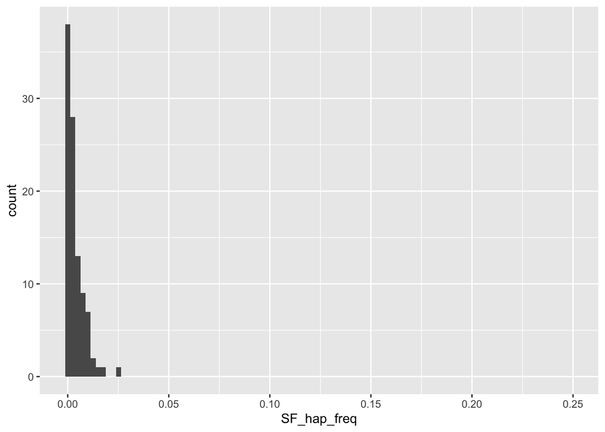

```r
Normal_rho100 <- tibble(Rep = 1:100) %>%
  group_by(Rep) %>%
  dplyr::do(discrete_coal_w_recomb(N = 9092, r = 0.000255, n = 898, g = 3, Y = 180))

result_normal_rho <- Normal_rho100 %>%
  group_by(Rep) %>%
  do(count_haplotypes(.))

# and plot a histogram of the S,F haplotype freqs
normal_rho_plot <- result_normal_rho %>%
  filter(P_Allele == "F" & R_Allele == "F") %>%
  mutate(SF_hap_freq = 1 - freq) %>%
  ggplot(., aes(x = SF_hap_freq)) +
  geom_histogram(bins = 100) +
  scale_x_continuous(limits = c(NA, 0.25))

normal_rho_plot
```

## Crank up the recombination rate to 10 cM/Mb

Make the recombination rate 10 cM/Mb:

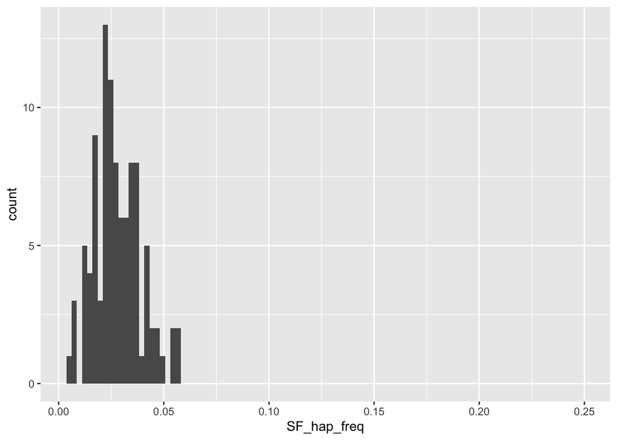

```r
rho_10X_500 <- tibble(Rep = 1:100) %>%
  group_by(Rep) %>%
  dplyr::do(discrete_coal_w_recomb(N = 9092, r = 0.00255, n = 898, g = 3, Y = 180))

result_rho_10X <- rho_10X_500 %>%
  group_by(Rep) %>%
  do(count_haplotypes(.))

# and plot a histogram of the S,F haplotype freqs
rho_10X_plot <- result_rho_10X %>%
  filter(P_Allele == "F" & R_Allele == "F") %>%
  mutate(SF_hap_freq = 1 - freq) %>%
  ggplot(., aes(x = SF_hap_freq)) +
  geom_histogram(bins = 100) +
  scale_x_continuous(limits = c(NA, 0.25))

rho_10X_plot
```

## save things that we might want to come back to

```r
save(result_normal_rho,
  result_rho_10X,
  normal_rho_plot,
  rho_10X_plot,
  file = "outputs/012/results-and-plots.rda",
  compress = "xz"
)
```

## Make some final figures:

```r
two_rhos <- list(
  `1 cM/Mb` = result_normal_rho,
  `10 cM/Mb` = result_rho_10X
) %>%
  bind_rows(.id = "recomb_rate")

final_plot <- two_rhos %>%
  filter(P_Allele == "F" & R_Allele == "F") %>%
  mutate(SF_hap_freq = 1 - freq) %>%
  ggplot(., aes(x = SF_hap_freq)) +
  geom_histogram(bins = 100) +
  scale_x_continuous(limits = c(NA, 0.25)) +
  facet_wrap(~recomb_rate, nrow = 1) +
  theme_bw() +
  geom_vline(xintercept = 0.22, color = "red") +
  xlab("Frequency of E/L haplotype in simulated sample") +
  ylab("Number of simulations (out of 100)")

ggsave(final_plot, filename = "outputs/012/prince-rosa-recomb-histos.pdf", width = 7, height = 4)
```

# Running Time

Running the code and rendering this notebook required approximately this much time on a Mac laptop of middling speed:

```r
Sys.time() - start_time
```

```
## Time difference of 4.197747 mins
```

Citations